IE 360-HW2- Ödül Tüfekçi 2018402180

Introduction: In this homework, I am forecasting the sales of UGS for every quarter of 2007 by using the data from years between 2000 and 2006 and a bunch of potential independent variables.

Preparing the Data:

```r
install.packages("corrplot")
install.packages("ggcorrplot")
install.packages("GGally")
install.packages("forecast")
install.packages("dplyr")
install.packages("RcppRoll")
install.packages("readxl")
install.packages("lubridate")
install.packages("zoo")
install.packages("ggplot2")
install.packages("scales")
install.packages("data.table")
library(corrplot)
library(ggcorrplot)
library(GGally)
library(forecast)
library(dplyr)
library(RcppRoll)
library(readxl)
library(lubridate)
library(zoo)
library(ggplot2)
library(scales)
library(data.table)
```

```
  There is a binary version available but the source version is later:
         binary source needs_compilation
corrplot   0.88   0.92             FALSE
```

```
installing the source package 'corrplot'
```

[output not shown]

[output not shown]

[output not shown]

[output not shown]

```
installing the source package 'ggplot2'
```

[output not shown]

[output not shown]

[output not shown]

```r
getwd()
```

'C:/Users/odult'

```r
hw2data <- read.csv("IE360_Spring22_HW2_data.csv",colClasses=c('character',rep('numeric',10)))
summary(hw2data)
str(hw2data)
```

```
   Quarter          Unleaded.Gasoline.Sale..UGS.      RNUV
 Length:32          Min.   : 736580              Min.   :0.001200
 Class :character   1st Qu.: 876211              1st Qu.:0.004100
 Mode  :character   Median : 983573              Median :0.007250
                    Mean   : 987212              Mean   :0.008906
                    3rd Qu.:1097324              3rd Qu.:0.013150
                    Max.   :1370167              Max.   :0.020700
                    NA's   :4
 X..LPG.Vehicles..NLPG. Price.of.Unleaded.Gasoline..PU.
 Min.   : 940000        Min.   :402.1
 1st Qu.: 997500        1st Qu.:479.2
 Median :1352000        Median :526.7
 Mean   :1299922        Mean   :519.2
 3rd Qu.:1602000        3rd Qu.:565.2
 Max.   :1797400        Max.   :609.0

 Price.of.Diesel.Gasoline..PG. X..Unleaded.Gasoline.Vehicles..NUGV.
 Min.   :300.7                 Min.   :4647500
 1st Qu.:366.9                 1st Qu.:5029281
 Median :401.6                 Median :5186068
 Mean   :400.4                 Mean   :5296758
 3rd Qu.:449.2                 3rd Qu.:5604709
 Max.   :471.9                 Max.   :6065597

 X..of.Diesel.Gasoline.Vehicles..NDGV. GNP.Agriculture    GNP.Commerce
 Min.   :282.0                         Min.   : 832953   Min.   :3374849
 1st Qu.:286.6                         1st Qu.:1348066   1st Qu.:4403081
 Median :291.9                         Median :1850657   Median :5124300
 Mean   :304.9                         Mean   :2895561   Mean   :5246534
 3rd Qu.:322.9                         3rd Qu.:3922950   3rd Qu.:5967433
 Max.   :357.3                         Max.   :7140722   Max.   :7480414

   GNP.Total
 Min.   :15832648
 1st Qu.:21790148
 Median :25229712
 Mean   :25745763
 3rd Qu.:29843404
 Max.   :36741745
```

```
'data.frame':	32 obs. of  11 variables:
 $ Quarter                              : chr  "2000_Q1" "2000_Q2" "2000_Q3" "2000_Q4" ...
 $ Unleaded.Gasoline.Sale..UGS.         : num  1128971 1199569 1370167 1127548 1033918 ...
 $ RNUV                                 : num  0.0146 0.0205 0.0207 0.0163 0.0071 0.0051 0.0041 0.0048 0.0012 0.0032 ...
 $ X..LPG.Vehicles..NLPG.               : num  940000 941000 943500 948000 950000 ...
 $ Price.of.Unleaded.Gasoline..PU.      : num  469 459 440 402 412 ...
 $ Price.of.Diesel.Gasoline..PG.        : num  356 345 327 301 306 ...
 $ X..Unleaded.Gasoline.Vehicles..NUGV. : num  4647500 4742876 4840931 4919685 4954754 ...
 $ X..of.Diesel.Gasoline.Vehicles..NDGV.: num  282 284 287 288 288 ...
 $ GNP.Agriculture                      : num  1040173 1760460 6974808 3267125 1004528 ...
 $ GNP.Commerce                         : num  3483132 4525451 5915204 4929778 3418387 ...
 $ GNP.Total                            : num  18022686 21797130 30050207 24480153 15832648 ...
```

```r
colnames(hw2data) <- c("Quarter", "UGS", "RNUV","NLPG","PU","PG","NUGV","NDGV","GNPA","GNPC","GNPT")
hw2data
```

[output not shown]

```r
hw2data$Quarter=as.Date(as.yearqtr(hw2data$Quarter,format="%Y_Q%q"))
hw2data_training=data.table(hw2data[c(1:28),])
hw2data_forecast=data.table(hw2data[c(29,30,31,32),])
```

```r
str(hw2data_training)
str(hw2data_forecast)
```

[output not shown]

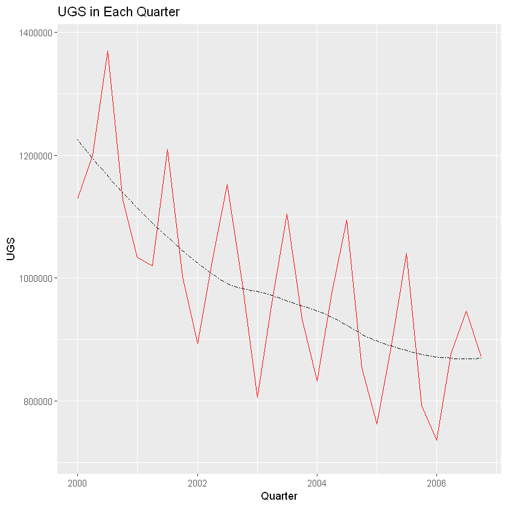

```r
ggplot1 <- ggplot(data = hw2data_training,aes(x = Quarter,y = UGS))
ggplot1 + geom_line(color ="red") +
  geom_smooth(fill = NA, color="black",linetype = "twodash", size = 0.5) +
  labs(title = "UGS in Each Quarter",
       x = "Quarter",
       y = "UGS" )
```

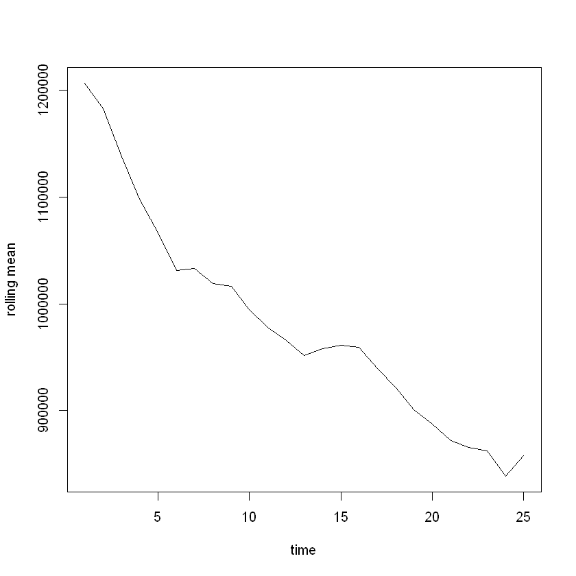

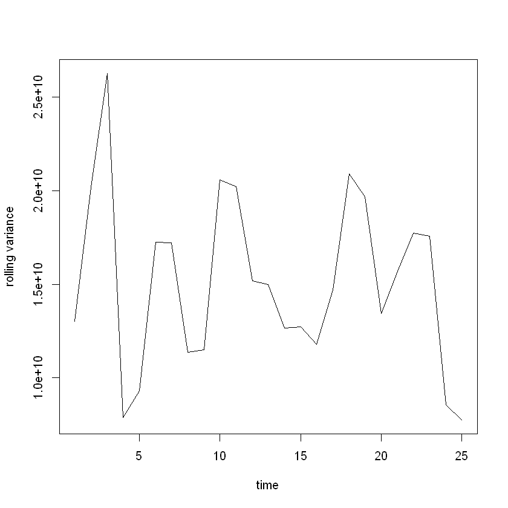

```r
mean=roll_mean(hw2data_training$UGS,4,align='left')
plot(mean,
     type='l',col='black',
     xlab = "time",
     ylab = "rolling mean")
var=roll_var(hw2data_training$UGS,4,align='left')
plot(var,
     type='l',col='black',
     xlab = "time",
     ylab = "rolling variance"
    )
```

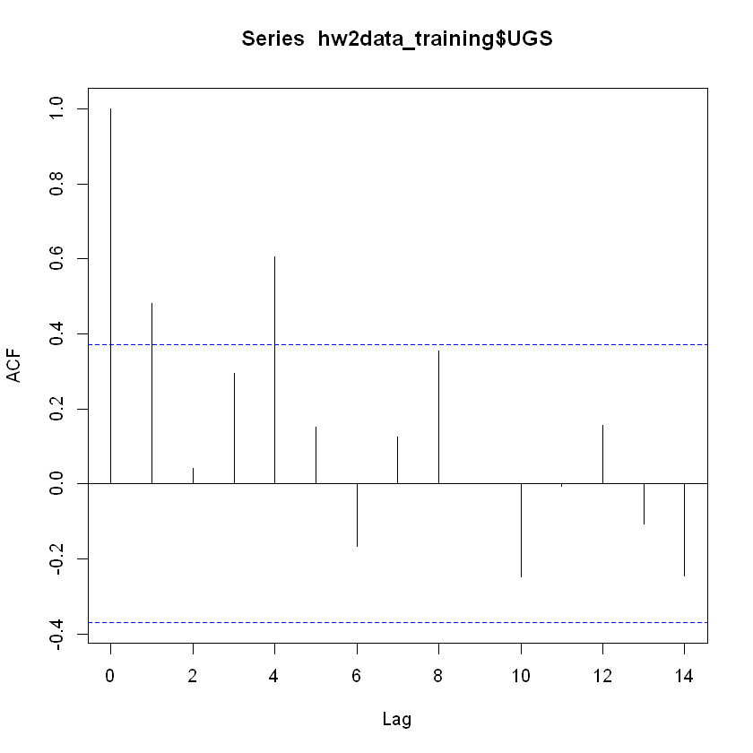

```r
acf(hw2data_training$UGS)
```

Model 1 - Adding Trend and Seasonality Data has strong trend and seasonality variables so in model1 I added these variables into my model and look for the results.

```r
hw2data_training[,trend := 1:.N ]
hw2data_training[,Quarter_:=as.character(month(Quarter))]
hw2data_forecast[,trend := 29:32 ]
hw2data_forecast[,Quarter_:=as.character(month(Quarter))]
model1 <- lm(UGS ~ trend+Quarter_, hw2data_training)
model1
summary(model1)
```

```
Call:
lm(formula = UGS ~ trend + Quarter_, data = hw2data_training)

Coefficients:
(Intercept)        trend   Quarter_10    Quarter_4    Quarter_7
    1060372       -13497        95049       121532       273618
```

```
Call:
lm(formula = UGS ~ trend + Quarter_, data = hw2data_training)

Residuals:
   Min     1Q Median     3Q    Max
-81167 -31283  -3458  28640  94502

Coefficients:
            Estimate Std. Error t value Pr(>|t|)
(Intercept)  1060372      23653  44.830  < 2e-16 ***
trend         -13497       1147 -11.764 3.28e-11 ***
Quarter_10     95049      26189   3.629 0.001405 **
Quarter_4     121532      25987   4.677 0.000104 ***
Quarter_7     273619      26063  10.498 3.03e-10 ***
---
Signif. codes:  0 '***' 0.001 '**' 0.01 '*' 0.05 '.' 0.1 ' ' 1

Residual standard error: 48570 on 23 degrees of freedom
Multiple R-squared:  0.9119,	Adjusted R-squared:  0.8966
F-statistic: 59.53 on 4 and 23 DF,  p-value: 8.446e-12
```

In this model, I obtained low residual standard error and a good R squared value.

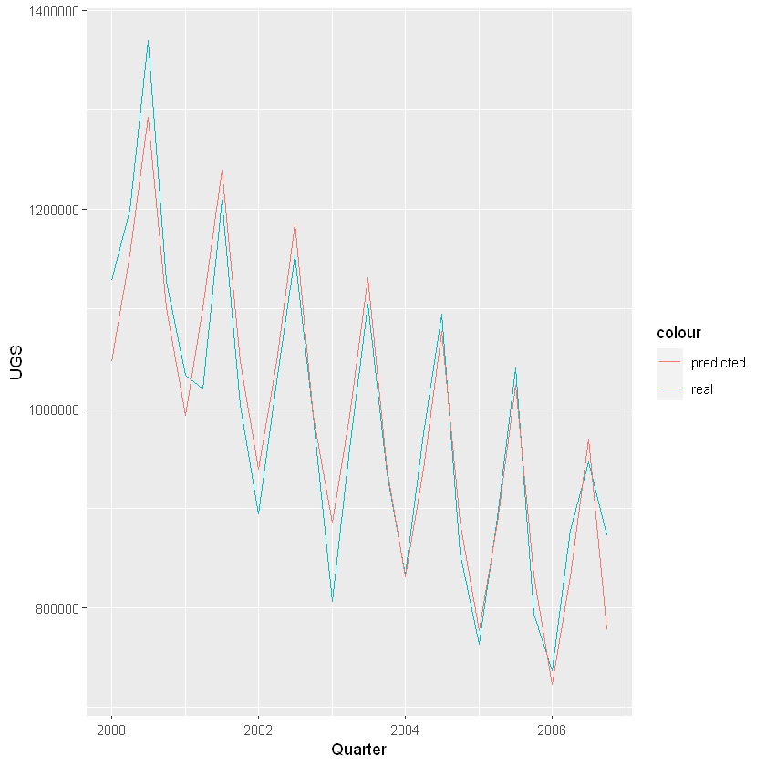

```r
pm1=copy(hw2data_training)
pm1[,actual:=UGS]
pm1[,pt:=predict(model1,pm1)]
pm1[,rt:=actual-pt]
ggplot(pm1 ,aes(x=Quarter)) +
        geom_line(aes(y=UGS,color='real')) +
        geom_line(aes(y=pt,color='predicted'))
```

Actual values and predicted values are really close to each other which shows that my model is good, however there are some errors which are called residuals. I will look at them and try to come up with a better model.

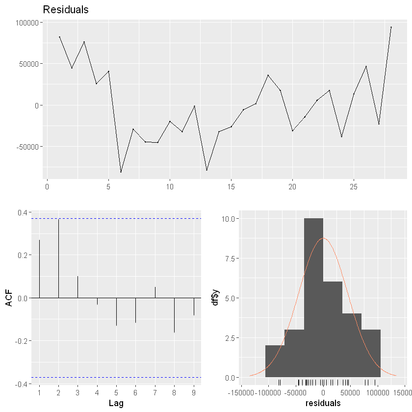

```r
checkresiduals(model1$residuals)
```

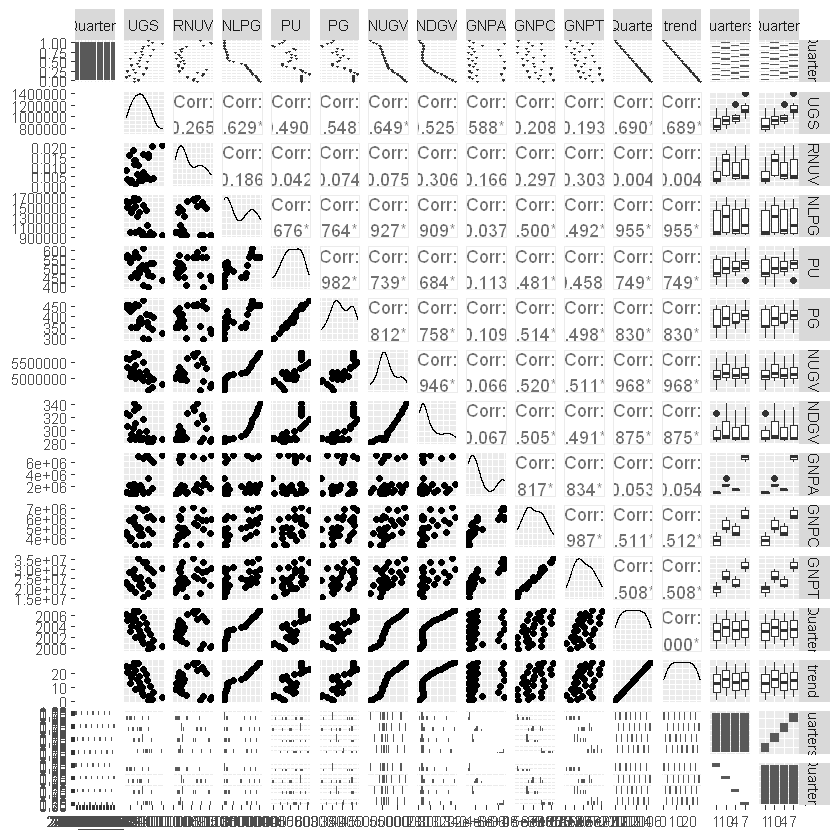

```r
ggpairs(hw2data_training, cardinality_threshold=30)
```

UGS is highly correlated with NLPG,PU,PG,NUGV,NDGV and GNPA attributes.

Adding Lags and Regressors to the Model: Output attribute has a significant seasonality and seasonality frequency is 4 so looking at lag1 and lag5 's values can make us to help a better prediction. Adding lagged values of both input attributes and output attribute will help us in improving our model.

```r
hw2data_training$UGSlag1=lag(hw2data_training$UGS,1)
hw2data_training$NUGVlag5=lag(hw2data_training$NUGV,5)
hw2data_training$NDGVlag5=lag(hw2data_training$NDGV,5)
model2 <-  lm(UGS ~ trend+PU+PG+NUGV+NDGV+GNPA +UGSlag1+NUGVlag5+NDGVlag5 + Quarter_, hw2data_training)
summary(model2)
```

```
Call:
lm(formula = UGS ~ trend + PU + PG + NUGV + NDGV + GNPA + UGSlag1 +
    NUGVlag5 + NDGVlag5 + Quarter_, data = hw2data_training)

Residuals:
   Min     1Q Median     3Q    Max
-40066  -9627    872  10043  30592

Coefficients:
              Estimate Std. Error t value Pr(>|t|)
(Intercept)  3.976e+06  1.964e+06   2.025  0.07042 .
trend        1.154e+04  2.183e+04   0.528  0.60877
PU          -5.700e+02  9.344e+02  -0.610  0.55545
PG           3.417e+02  1.217e+03   0.281  0.78468
NUGV        -1.447e+00  5.427e-01  -2.666  0.02363 *
NDGV         9.099e+03  4.166e+03   2.184  0.05388 .
GNPA        -7.666e-03  4.206e-02  -0.182  0.85901
UGSlag1     -4.674e-01  2.370e-01  -1.972  0.07690 .
NUGVlag5    -1.654e-01  4.570e-01  -0.362  0.72490
NDGVlag5     1.019e+04  9.590e+03   1.062  0.31304
Quarter_10   2.225e+05  4.861e+04   4.578  0.00101 **
Quarter_4    1.127e+05  4.237e+04   2.660  0.02389 *
Quarter_7    3.542e+05  2.337e+05   1.515  0.16064
---
Signif. codes:  0 '***' 0.001 '**' 0.01 '*' 0.05 '.' 0.1 ' ' 1

Residual standard error: 24500 on 10 degrees of freedom
  (5 observations deleted due to missingness)
Multiple R-squared:  0.9826,	Adjusted R-squared:  0.9617
F-statistic: 47.08 on 12 and 10 DF,  p-value: 3.727e-07
```

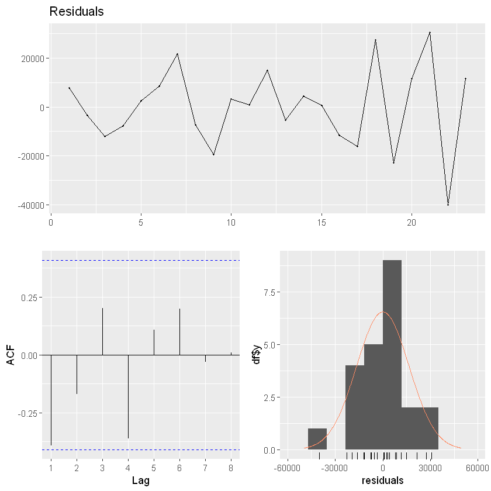

```r
checkresiduals(model2$residuals)
```

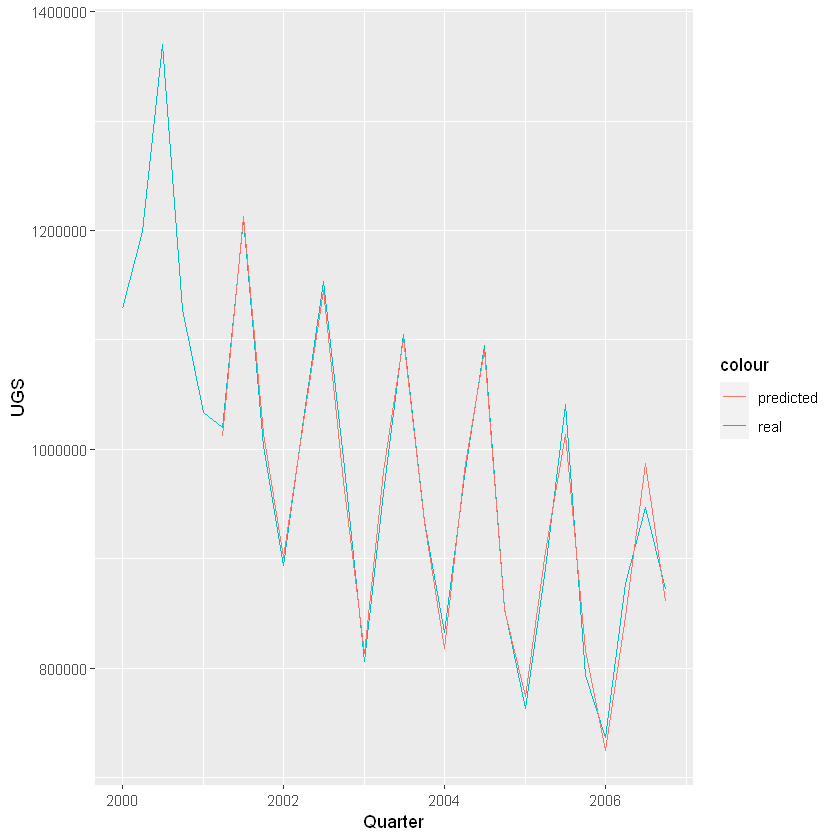

```r
pm2=copy(hw2data_training)
pm2[,actual:=UGS]
pm2[,pt:=predict(model2,pm2)]
pm2[,rt:=actual-pt]
ggplot(pm2 ,aes(x=Quarter)) +
        geom_line(aes(y=UGS,color='real')) +
        geom_line(aes(y=pt,color='predicted'))
```

Removing Lags From The Model: I tried to remove lags from the model and see that if i can obtain a good model by just adding the regressors. I guess that it make worse my model. However I want to see it by comparing my previous model.

```r
model3= lm(UGS ~ trend+NLPG+PU+PG+NUGV+NDGV+GNPA + Quarter_, hw2data_training)
summary(model3)
```

```
Call:
lm(formula = UGS ~ trend + NLPG + PU + PG + NUGV + NDGV + GNPA +
    Quarter_, data = hw2data_training)

Residuals:
   Min     1Q Median     3Q    Max
-67794 -10461   1987  18461  32208

Coefficients:
              Estimate Std. Error t value Pr(>|t|)
(Intercept)  3.094e+06  8.283e+05   3.735  0.00165 **
trend        1.514e+04  1.284e+04   1.178  0.25486
NLPG        -2.937e-01  1.804e-01  -1.628  0.12195
PU           2.276e+01  1.017e+03   0.022  0.98241
PG          -1.129e+03  1.437e+03  -0.786  0.44295
NUGV        -1.023e+00  3.343e-01  -3.061  0.00708 **
NDGV         1.238e+04  3.581e+03   3.456  0.00302 **
GNPA        -3.613e-02  2.764e-02  -1.307  0.20854
Quarter_10   1.607e+05  4.385e+04   3.664  0.00192 **
Quarter_4    1.463e+05  2.356e+04   6.212 9.48e-06 ***
Quarter_7    4.953e+05  1.597e+05   3.102  0.00648 **
---
Signif. codes:  0 '***' 0.001 '**' 0.01 '*' 0.05 '.' 0.1 ' ' 1

Residual standard error: 29700 on 17 degrees of freedom
Multiple R-squared:  0.9757,	Adjusted R-squared:  0.9613
F-statistic: 68.12 on 10 and 17 DF,  p-value: 1.055e-11
```